# 10. XAI

Michał Maj

2021-05-11

# 1 XAI

## 1.1 Wyjaśnialna sztuczna inteligencja

**Wyjaśnialna sztuczna inteligencja** (XAI) to subdziedzina Machine Learningu zajmująca się wyjasnianiem modeli statystycznych (zazwyczaj skomplikowanych “black boxów”) jak równiez ich predykcji. W dzisiejszych czasach objaśnienie decyzji modeli ML nie wynika tylko z chęci zrozumienia wspomnianego modelu, a w niektórych przypadkach z wymogów prawnych. Przykładowo w bankowości i finansach klient ma tak zwane [“prawo do wyjaśnienia”](https://en.wikipedia.org/wiki/Right_to_explanation) - na przykład w przypadku odmowy kredytu klient może wnioskowac o uzasadnienie… powiedzenie wtedy, że “tak zdecydowała siec neuronowa” nie będzie akceptowalne. Innym przykładem może być medycyna - lekarze nie znający się na ML musza zrozumieć dlaczego podana została taka a nie inna diagnoza.

Metody XAI możemy podzialić na kilka różnych typów w zalezności od ich działania:

1. Czy metodę mozna zastosować dla dowolnego modelu?
- Tak: Model Agnostic
- Nie: Model Specific
2. Czy metoda tłumaczy cały model czy tylko jego część/próbkę?
- Tak: Global
- Nie: Local
3. Przez co nastepuje tłumaczenie modelu?
- Uproszczenie modelu: Suggogate model
- Istotność zmiennych: Variable importance
- Wizualizacja: Vizualization

## 1.2 DALEX

`DALEX` czyli **moDel Agnostic Language for Exploration and eXplanation** jest to pakiet R zawierający zestaw narzędzi agnostycznego wyjaśniania modeli i ich predykcji.

Zacznijmy od inspecki zbioru `apartments`:

```r
head(apartments)
```

```
##   m2.price construction.year surface floor no.rooms    district
## 1     5897              1953      25     3        1 Srodmiescie
## 2     1818              1992     143     9        5     Bielany
## 3     3643              1937      56     1        2       Praga
## 4     3517              1995      93     7        3      Ochota
## 5     3013              1992     144     6        5     Mokotow
## 6     5795              1926      61     6        2 Srodmiescie
```

Został o utworzony w ten sposób, że znamy prawdziwą funkcję regresji dla zmiennej objasnianej `m2.price`:

$$m2.price = \\
5000+600∗(|construction.year−1965|>30)−10∗surface−100∗floor−50∗no.rooms+1.5∗district$$

Zdudujmy teraz dwa modele statystyczne dla powyższego zjawiska:

```r
regr_lm <- lm(m2.price ~ ., data = apartments)
regr_rf <- randomForest(m2.price ~ ., data = apartments)
```

Aby móc korzystać z metod wyjaśnialności pakietu `DALEX` musimy najpierw stwprzyć obiekt klasy `explainer`:

```r
explainer_lm <- explain(regr_lm, # Model do wytlumaczenia
                        data = apartmentsTest[ , 2:6], # Predyktory
                        y = apartmentsTest$m2.price, # Zmienna objaśniana
                        label = "lm") # Label do wykresów
```

```
## Preparation of a new explainer is initiated
##   -> model label       :  lm
##   -> data              :  9000  rows  5  cols
##   -> target variable   :  9000  values
##   -> predict function  :  yhat.lm  will be used (  default  )
##   -> predicted values  :  No value for predict function target column. (  default  )
##   -> model_info        :  package stats , ver. 4.0.3 , task regression (  default  )
##   -> predicted values  :  numerical, min =  1792.597 , mean =  3506.836 , max =  6241.447
##   -> residual function :  difference between y and yhat (  default  )
##   -> residuals         :  numerical, min =  -257.2555 , mean =  4.687686 , max =  472.356
##   A new explainer has been created!
```

```r
explainer_rf <- explain(regr_rf,
                        data = apartmentsTest[ , 2:6],
                        y = apartmentsTest$m2.price,
                        label = "rf")
```

```
## Preparation of a new explainer is initiated
##   -> model label       :  rf
##   -> data              :  9000  rows  5  cols
##   -> target variable   :  9000  values
##   -> predict function  :  yhat.randomForest  will be used (  default  )
##   -> predicted values  :  No value for predict function target column. (  default  )
##   -> model_info        :  package randomForest , ver. 4.6.14 , task regression (  default  )
##   -> predicted values  :  numerical, min =  1978.28 , mean =  3507.533 , max =  5803.647
##   -> residual function :  difference between y and yhat (  default  )
##   -> residuals         :  numerical, min =  -756.0362 , mean =  3.990355 , max =  1298.186
##   A new explainer has been created!
```

Stworzymy także funkcje pomocnicza odpowiadająca za predykcje (model “prawdziwy”):

```r
true_relation <- function(x1, x2, x3, x4, x5){
  levels(x5) <- c(-400, -400, 200, 200, -400, 1000, -400, -400, -400, 200)
  x5 <- as.numeric(as.character(x5))
  5000 +  600 * (abs(x1 - 1965) > 30) - 10 * x2 - 100 * x3 -50 * x4 + 1.5 * x5
}
explainer_tr <- explain(
  regr_lm, # Bez różnicy co tu podamy, bo nie jest wykorzystywane w predict_function
  data = apartmentsTest[ , 2:6],
  y = apartmentsTest$m2.price,
  predict_function = function(m, x) true_relation(x[,1], x[,2], x[,3], x[,4], x[,5]),
  label = "True Model")
```

```
## Preparation of a new explainer is initiated
##   -> model label       :  True Model
##   -> data              :  9000  rows  5  cols
##   -> target variable   :  9000  values
##   -> predict function  :  function(m, x) true_relation(x[, 1], x[, 2], x[, 3], x[, 4],      x[, 5])
##   -> predicted values  :  No value for predict function target column. (  default  )
##   -> model_info        :  package stats , ver. 4.0.3 , task regression (  default  )
##   -> predicted values  :  numerical, min =  1600 , mean =  3504.371 , max =  6680
##   -> residual function :  difference between y and yhat (  default  )
##   -> residuals         :  numerical, min =  -5 , mean =  7.152444 , max =  605
##   A new explainer has been created!
```

Pierwszą rzeczą jaka mozemy sprawdzić jest rozkład reszt:

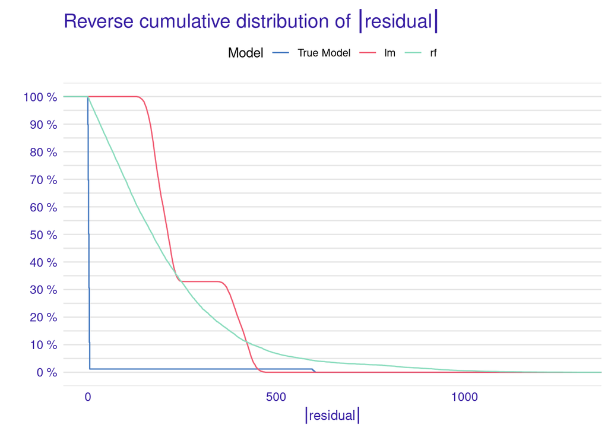

```r
mp_lm <- model_performance(explainer_lm) # Zwykła dystrybuanta empiryczna reszt
mp_rf <- model_performance(explainer_rf)
mp_tr <- model_performance(explainer_tr)

plot(mp_lm, mp_rf, mp_tr)
```

Kolejną rzeczą, którą możemy sprawdzić jest istotność poszczególnych zmiennych:

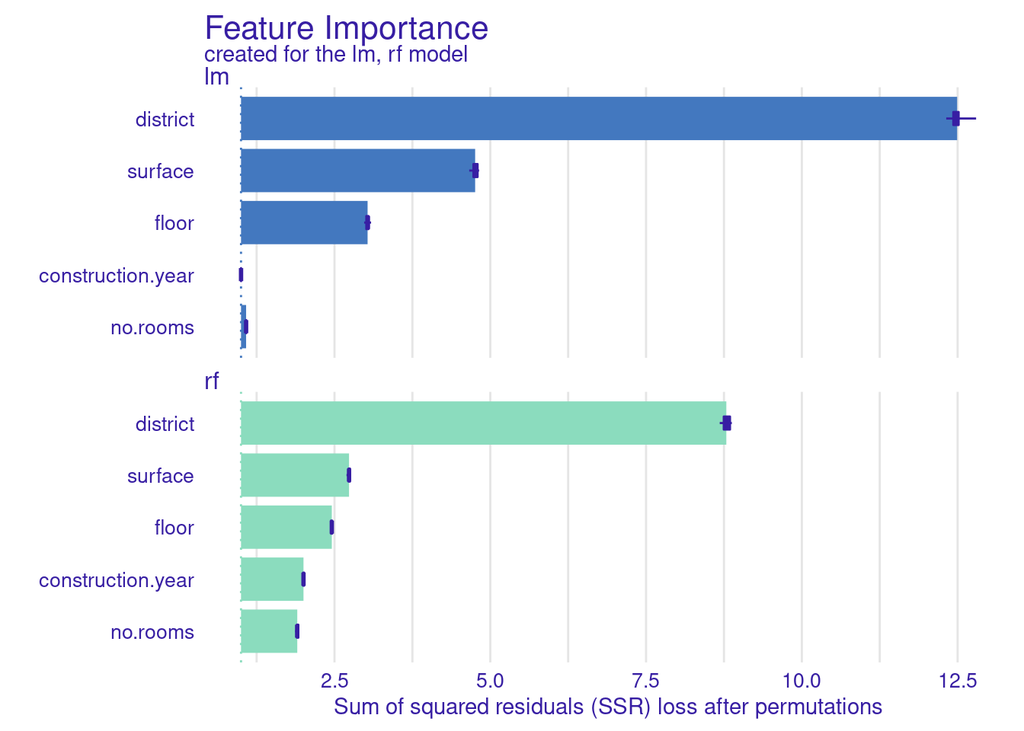

```r
set.seed(1234)
vi_lm <- model_parts(explainer_lm, # Explainer
                     loss_function = loss_sum_of_squares, # Funkcja straty
                     type = "ratio", # Typ transforacji dla funkcji straty z dropoutu
                     n_sample = 9000) # Samplowanie próbek ze zbioru
vi_rf <- model_parts(explainer_rf,
                     loss_function = loss_sum_of_squares,
                     type = "ratio",
                     n_sample = 9000)
vi_tr <- model_parts(explainer_tr,
                     loss_function = loss_sum_of_squares,
                     type = "ratio",
                     n_sample = 9000)
plot(vi_lm, vi_rf)
```

W tym miejscu wyjaśnijmy co się stało. Idea powyższego algorytmu jest bardzo prosta. Powyższe wykresy odpowiadają na pytanie “ile razy wzrośnie funkcja straty jeśli dany predyktor zostałby zrandomizowany”? Jeśli wartość wzrostu funkcji straty po randomizacji jest duża to zmienna jest istotna. Takie podejście daje nam mozliwość testowania istotności zmiennych dla dowolnej klasy modeli ML - agnostycznie.

```r
x <- apartmentsTest[ , 2:6]
y <- apartmentsTest$m2.price
loss_0 <- loss_sum_of_squares(y, predict(regr_lm, x)) # Oznaczonae jako _full_model_
```

Nastepnie sprawdzamy jak wyglądałaby nasza funkcja straty po randomizacji wszystkich zmiennych:

```r
set.seed(1234)
loss_full <- loss_sum_of_squares(sample(y), predict(regr_lm, x)) # Oznaczonae jako _baseline_ (Randomizacja wszystkich zmiennych)
```

Nastepnie sprawdzamy wartości funkcji straty randomizując jedną zmienną na raz:

```r
variables <- colnames(x)
res <- sapply(variables, function(variable) {
  ndf <- x
  ndf[, variable] <- sample(ndf[, variable]) # Randomizacja danej zmiennej
  predicted <- predict(regr_lm, ndf) # Predykcje po randomizacji
  loss_sum_of_squares(y, predicted) # Wartosc funkcji straty po randomizacji
})
res/loss_0 # Ile razy wzrosła funkcja straty po randomizacji zmiennej. Wartości bliskie 1 oznaczają zmienną nieistotną, im wyższe tym bardziej istotne
```

```
## construction.year           surface             floor          no.rooms
##          1.000420          4.755204          2.975884          1.080582
##          district
##         12.461279
```

Jesli znamy już istotności poszczególnych zmiennych może nas interesować jaki wpływ (liniowy bądź nie) mają one na nasze predykcje. Istnieje kilka różnych algorytmów badających wspomnianą zależność. Zaczniemy od **Partial Dependence Plots - PDP** zdefiniowanej jako oczekiwana wartość prognoz/predykcji gdy zmienna $X_j$ przyjmuje wartość $z$ nad rozkładem marginalnym pozostałych predyktorów $X_{-j}$.

$$P D P^{j}(z)=E_{\underline{X}^{-j}}\left\{f\left(X^{j \mid=z}\right)\right\}$$
Oczywiście rozkład zmiennych $X_j$ jest zazwyczaj nieznany, dlatego PDP estymujemy korzystając ze wzoru:

$$\hat{P D P}^{j}(z)= \frac{1}{n} \sum_{i=1}^n f(\underline{x}_i^{j \mid=z})$$

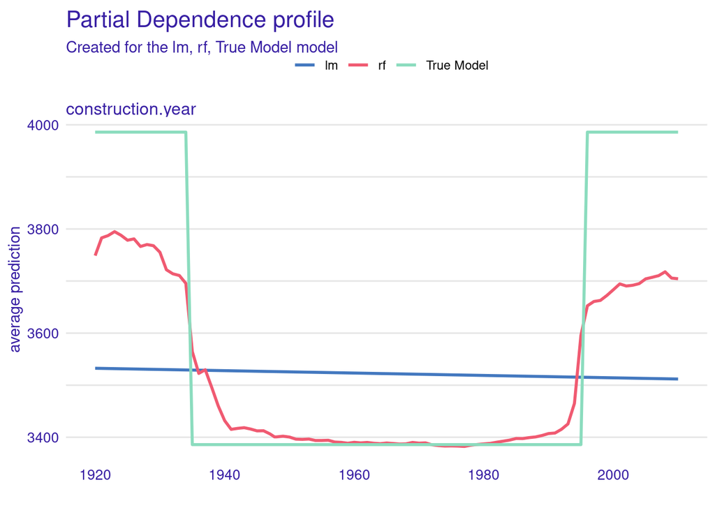

```r
sv_lm  <- model_profile(explainer_lm, # Explainer
                        variable =  "construction.year", # Zmienna, którą wyjaśniamy
                        type = "partial") # Typ : Partial Dependence Plot
sv_rf  <- model_profile(explainer_rf,
                        variable =  "construction.year",
                        type = "partial")
sv_tr <- model_profile(explainer_tr,
                       variable =  "construction.year",
                       type = "partial")
plot(sv_lm, sv_rf, sv_tr)
```

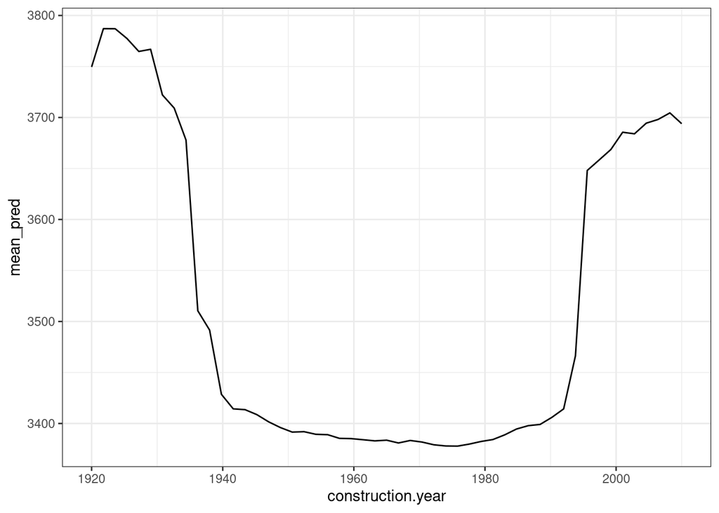

```r
unique_years <- seq(from = min(apartmentsTest$construction.year), to = max(apartmentsTest$construction.year), by = 1.8)
x <- unique_years %>% purrr::map_df(~ {
  apartmentsTest[ , 2:6] %>%
    mutate(construction.year = .x) %>% # Podmieniam wartość danej zmiennej w całym zbiorze
    bind_cols(., prediction = predict(regr_rf, .)) %>%
    group_by(construction.year) %>%
    summarise(mean_pred = mean(prediction))
})
ggplot(x, aes(construction.year, mean_pred)) + geom_line() + theme_bw()
```

Wadą PDP jest to, że w przypadku skorelowanych predyktorów wykresy te moga znacznie odbiegać od prawdy. Bardziej skomplikowaną alternatywą rozwiazujacą ten problem jest **Accumulated Local Effects - ALE**, w których to liczymy nasza wartość oczekiwaną dla rozkładu warunkowego, a nie marginalnego, a takze lokalnie a nie globalnie:

$$ALE^{j}(z)=\int_{z_{0}}^{z}\left[E_{\underline{X}^{-j} \mid X^{j}=v}\left\{q^{j}\left(\underline{X}^{j \mid=v}\right)\right\}\right] d v+c \\
q^{j}(\underline{u})=\left\{\frac{\partial f(\underline{x})}{\partial x^{j}}\right\}_{\underline{x}=\underline{u}}$$
ALE estymowane jest wzorem:

$$\hat{ALE}^{j}(z)==\sum_{k=1}^{k_{j}(z)} \frac{1}{n_{j}(k)} \sum_{i: x_{i}^{j} \in N_{j}(k)}\left\{f\left(\underline{x}_{i}^{j \mid=z_{k}^{j}}\right)-f\left(\underline{x}_{i}^{j \mid=z_{k-1}^{j}}\right)\right\}-\hat{c}$$
gdzie $\hat{c}$ wybrane jest w ten sposób, że

$$\sum_{i=1}^{n} \hat{ALE}^{f, j}\left(x_{i}^{j}\right)=0$$

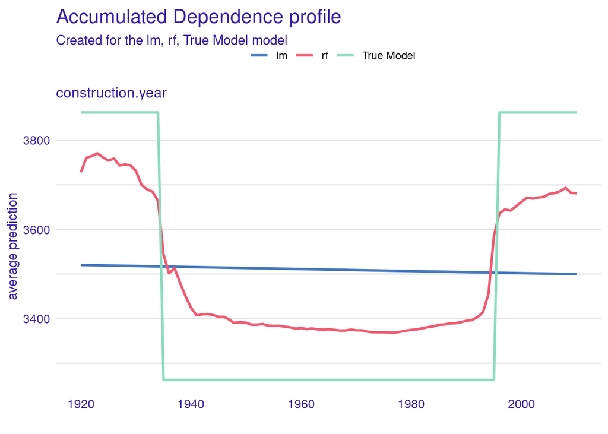

```r
sv2_lm  <- model_profile(explainer_lm, # Explainer
                         variable =  "construction.year", # Zmienna, którą wyjaśniamy
                         type = "accumulated") # Typ : Accumulated Local Effects
sv2_rf  <- model_profile(explainer_rf,
                         variable =  "construction.year",
                         type = "accumulated")
sv2_tr <- model_profile(explainer_tr,
                        variable =  "construction.year",
                        type = "accumulated")
plot(sv2_lm, sv2_rf, sv2_tr)
```

Mozna to policzyć recznie w następujący sposób

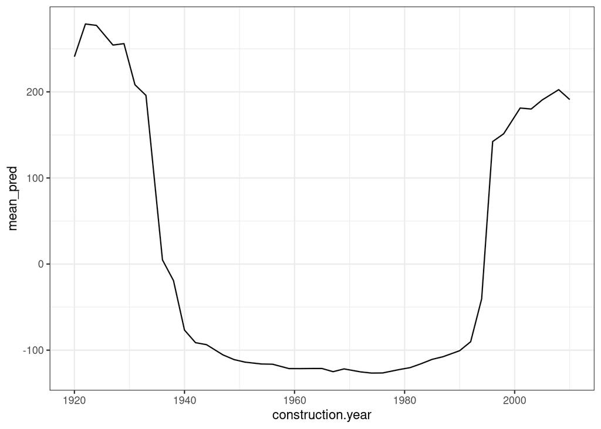

```r
X <- apartmentsTest[ , 2:6]
J <- "construction.year"
K <- 40
z <- c(min(X[, J]), as.numeric(quantile(X[, J], seq(1/K, 1, length.out = K), type = 1))) # Kwantyle zmiennej construction.year
a1 = as.numeric(cut(X[, J], breaks = z, include.lowest = TRUE)) # Podział na interwały
X1 = X
X2 = X
X1[, J] = z[a1] # Interwał po lewej
X2[, J] = z[a1 + 1] # Interwał po prawej
y.hat1 = predict(regr_rf, newdata = X1) # Predykcja dla lewego interwału
y.hat2 = predict(regr_rf, newdata = X2) # Predykcja dla prawego interwału
Delta = y.hat2 - y.hat1 # Aproksymacja gradientów
Delta = as.numeric(tapply(Delta, a1, mean)) # Wartość oczekiwana gradientów
fJ = c(0, cumsum(Delta))
b1 <- as.numeric(table(a1))
fJ = fJ - sum((fJ[1:K] + fJ[2:(K + 1)])/2 * b1)/sum(b1) # Sumowanie Efektów
x <- z
df <- data.frame(construction.year = x, mean_pred = fJ)
ggplot(df, aes(construction.year, mean_pred)) + geom_line() + theme_bw()
```

Jesli znamy już istotność i kształt zalezności zmiennych możemy przejść do tłumaczenia pojedynczej predykcji.

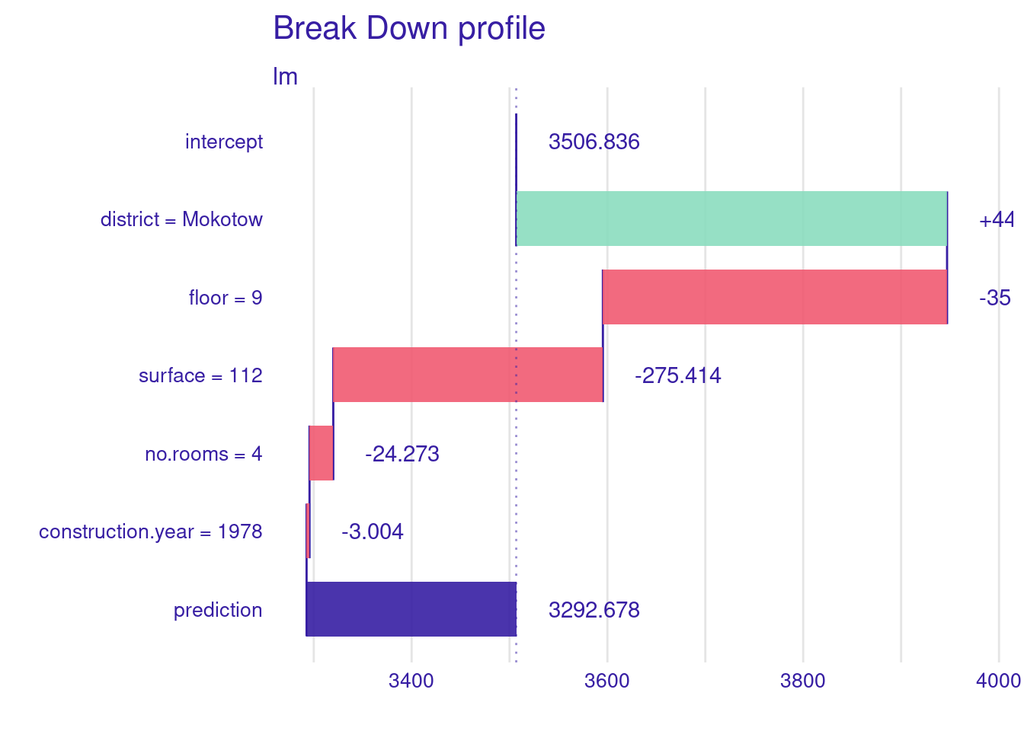

```r
obserwacja <- apartmentsTest[2 , 2:6]
pb_lm <- predict_parts(explainer_lm, obserwacja)
pb_rf <- predict_parts(explainer_rf, obserwacja)
pb_tr <- predict_parts(explainer_tr, obserwacja)

plot(pb_lm)
```

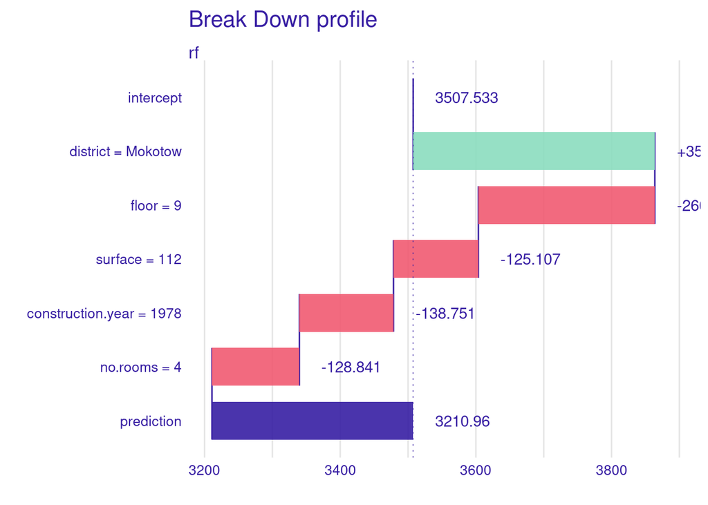

```r
plot(pb_rf)
```

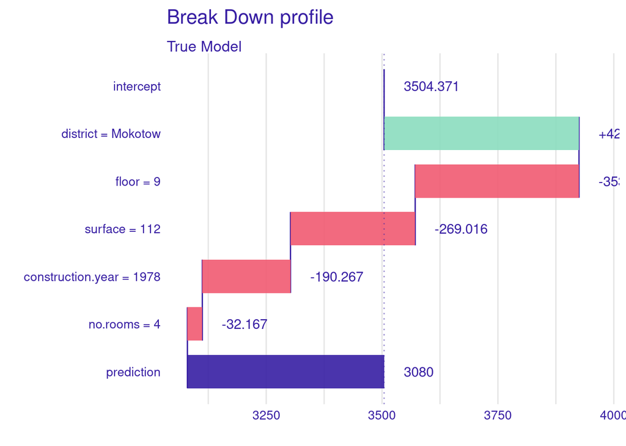

```r
plot(pb_tr)
```